# Functional analysis of regulated psites upon TCR stimulation

Marie Locard-Paulet

Tue Oct 23 10:02:08 2018

# Generation of the input data

## phosphorylation sites IDs

There are some issues with protein IDs. For peptide identification. Some peptides are ambiguous, they can belong to several proteins/proteoforms with common sequences. I keep the `Proteins` field in the raw table. This allows us to keep the information of what phosphosite could belong to several proteoforms and what the corresponding phosphorylation position in the protein sequence are. I have ordered them by alphabetical order.

To generate the phosphosite IDs, I keep all possible protein identifications (Uniprot entry names) separated by “;”, together with their respective positions separated by “;”.

## Filters and statistical analysis

See the data preparation in the document `DataPreparation.html`.

I log2-transform the data set. For each replicate independently, I calculate the mean of the injection replicates in each time point.

From there, I run a loop of 200 iterations that contain the following steps:

For each phosphorylation site, when it is not measured in any biological replicate for a condition (or only one biological replicate), I replace missing values with a random value generated around the 5% quantile of the intensities for each condition, using the standard deviation of the dataset (technical variance) per condition.

For each phosphorylation site, I normalise the biological replicates using the mean of the signal across all the conditions (after replacement of missing values).

I only keep the phosphorylation sites that have a minimum of 3 time points with values in the same 2 replicates.

I perform an anova on each phosphorylation site across the 6 time points. Then, I correct the pvalue with Tukey HSD.

I calculate the fold changes per time point relative to each other.

The thresholds for a phosphorylation site to be regulated is having a pvalue of the Anova under or equal to 0.05, and the best pvalue from Tukey under or equal to 0.05 with a corresponding absolute log2-transformed fold change above or equal to log2(1.75). I only keep the pvalue and FC for the comparisons where there are a minimum of 2 points per condition.

This is performed 200 times, then I keep as variants only the sites that pass these threshold a minimum of 90% of the times. All the fold change values reported are the averages of the 200 iterations.

# Results of the statistical analysis

Numbers:

Table of regulated amino-acids:

[output not shown]

Here, the pY are only counted in the pYIP and the S/T in the TiO2. I have counte the sites multiply phosphorylated as follows: “prot-S1+Y2” correspond to one serine and one tyrosine.

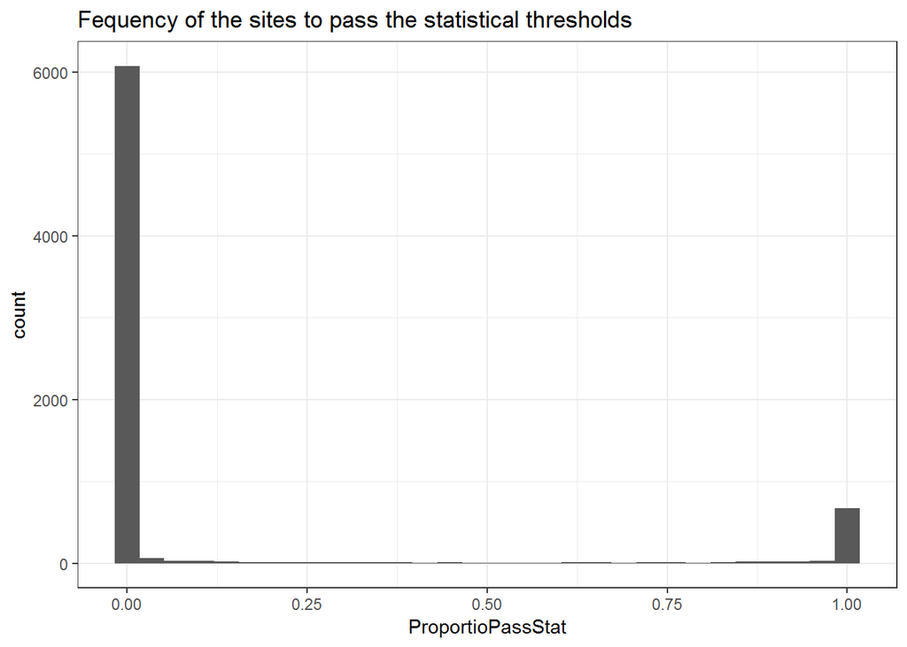

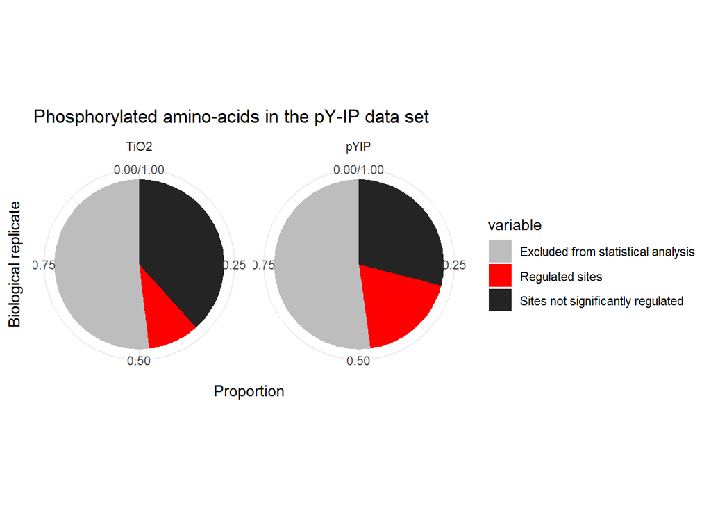

Total number of regulated phosphorylation sites: 731

# Global trends

Here I plot the quantification values relative to the unstimulated control for each data set, independently.

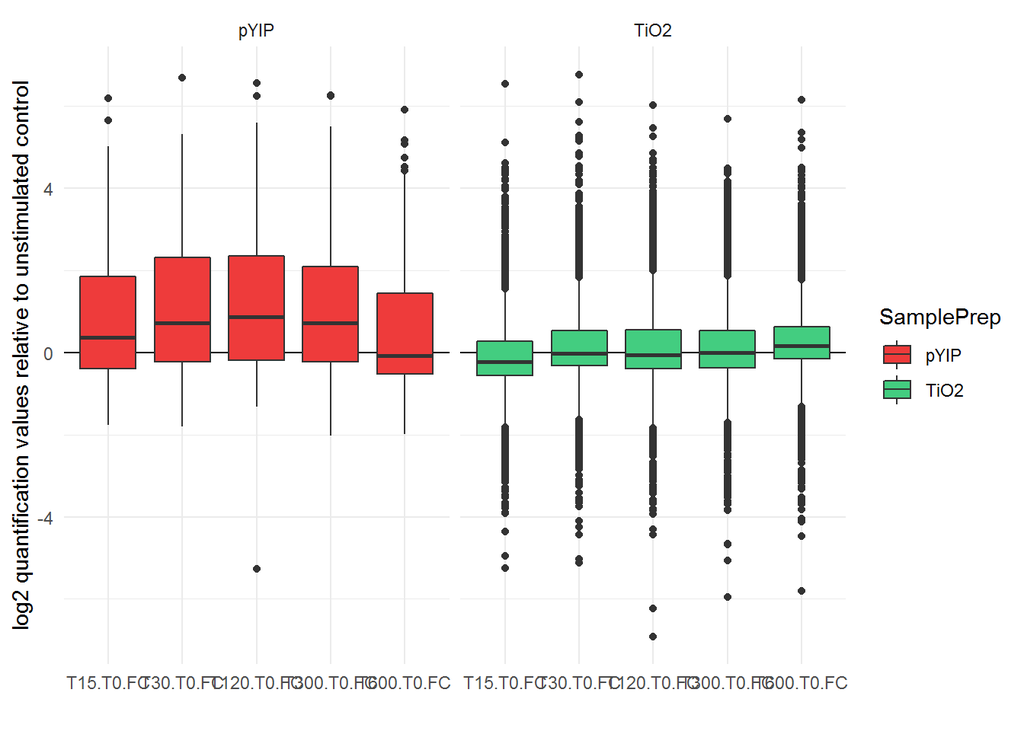

# Figure with number of regulated phosphorylation site per time point

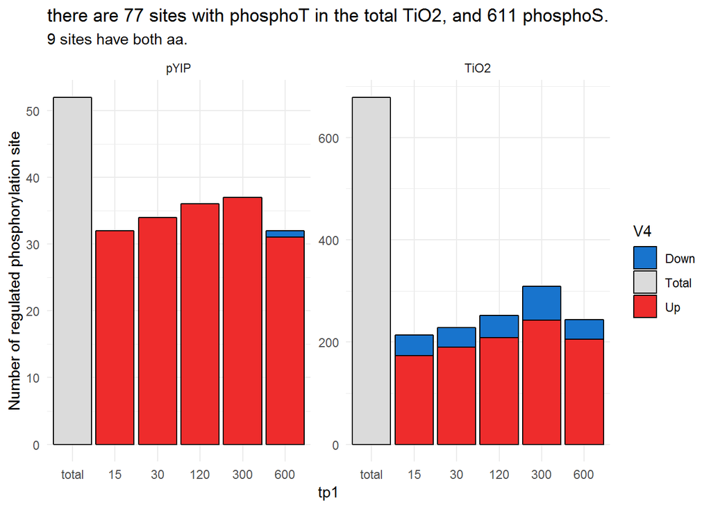

| TimePoint | value | SamplePrep | V4 | tp1 |
| --- | --- | --- | --- | --- |
| T120.T0 | 209 | TiO2 | Up | 120 |
| T15.T0 | 173 | TiO2 | Up | 15 |
| T30.T0 | 190 | TiO2 | Up | 30 |
| T300.T0 | 243 | TiO2 | Up | 300 |
| T600.T0 | 206 | TiO2 | Up | 600 |
| T120.T0 | 36 | pYIP | Up | 120 |
| T15.T0 | 32 | pYIP | Up | 15 |
| T30.T0 | 34 | pYIP | Up | 30 |
| T300.T0 | 37 | pYIP | Up | 300 |
| T600.T0 | 31 | pYIP | Up | 600 |
| T120.T0 | 43 | TiO2 | Down | 120 |
| T15.T0 | 41 | TiO2 | Down | 15 |
| T30.T0 | 38 | TiO2 | Down | 30 |
| T300.T0 | 66 | TiO2 | Down | 300 |
| T600.T0 | 38 | TiO2 | Down | 600 |
| T120.T0 | 0 | pYIP | Down | 120 |
| T15.T0 | 0 | pYIP | Down | 15 |
| T30.T0 | 0 | pYIP | Down | 30 |
| T300.T0 | 0 | pYIP | Down | 300 |
| T600.T0 | 1 | pYIP | Down | 600 |
| Total | 679 | TiO2 | Total | total |
| Total | 52 | pYIP | Total | total |

# Volcano plots of the anova:

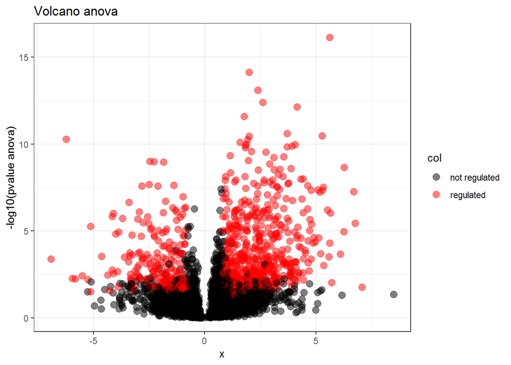

I also draw the volcano plots per time point in order to get a feel for the statistics at each time point. These are saved in `Figures`.

# Clustering

The scripts used for the clustering are in the folder `tsne` and were written by Romain Roncagalli. He used ClusterX to cluster the regulated phosphorylation sites based on their coordinate on a tsne representation.

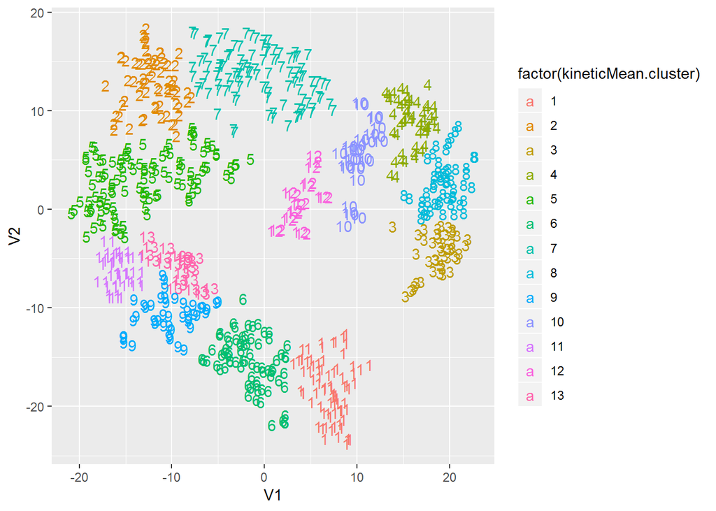

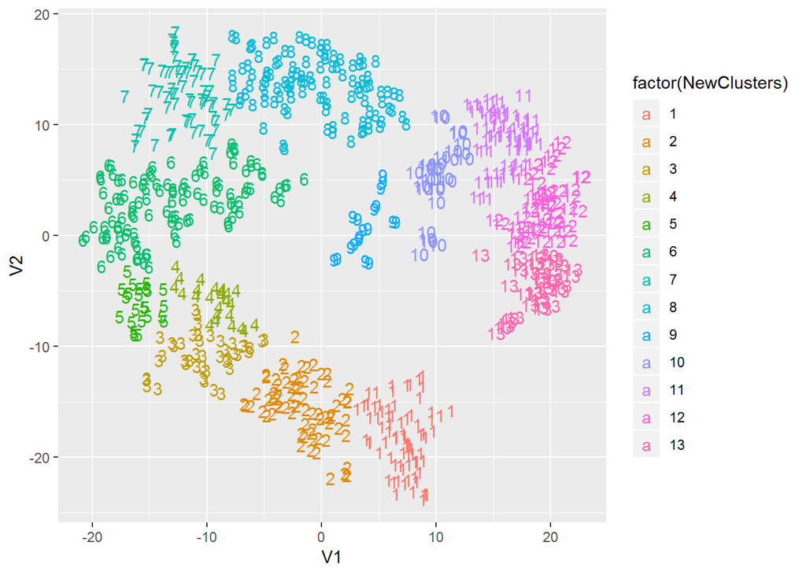

Graphical representation of the different clusters with real values: *Here I re-ordered the clusters for the paper based on their kinetic shape and not the number of site:*

```
##  [1] "A6H8H2_S1096"       "D3Z6Q9_T35"         "O08553_S542"
##  [4] "O35601_S27"         "O35601_S561"        "O54824_S792"
##  [7] "O54957_S49"         "O55098_S13"         "O70400_S183"
## [10] "O89100_S180"        "P06332_S439"        "P15702_S339"
## [13] "P16872_S375"        "P19973_S179"        "P28741_S689"
## [16] "P28867_Y311"        "P29352_Y535"        "P42209_S311"
## [19] "P70429_S343"        "P97814_S312"        "P98083_S139"
## [22] "Q3TBD2_S14"         "Q3TBD2_S66"         "Q3UHD9_S802"
## [25] "Q3UHX2_S176"        "Q3UHX2_T18"         "Q3UQ44_S764"
## [28] "Q5DU31_S307"        "Q5DU31_T166"        "Q5DU31_T308"
## [31] "Q60875_S122"        "Q60875_S885"        "Q60949_S231"
## [34] "Q60949_S521"        "Q62167_S90"         "Q640N3_S1048"
## [37] "Q6NXH3_S295"        "Q6NZJ6_S1081"       "Q6P5G6_S266"
## [40] "Q6PAR5_S902"        "Q6ZPZ3_S1270+S1276" "Q6ZQB6_S1066"
## [43] "Q78HU3_S168"        "Q80TY0_S496"        "Q80U28_S812"
## [46] "Q80U72_S1361"       "Q80U72_S1490"       "Q80UG5_S60"
## [49] "Q80UG5_S80"         "Q8BGD9_S283"        "Q8BGQ1_S119"
## [52] "Q8BTI8_S964"        "Q8BTI8_T2056"       "Q8BYW1_S2"
## [55] "Q8BZN6_S12"         "Q8C2K5_S883"        "Q8C3J5_S1722"
## [58] "Q8C3J5_S587"        "Q8CIN4_S197"        "Q8K1I7_S268"
## [61] "Q8K1I7_S330"        "Q8K285_S295"        "Q8K4G5_S496"
## [64] "Q8K4G5_S738"        "Q99K28_S239"        "Q99K28_S431"
## [67] "Q9CZ04_S255"        "Q9D1J1_S181"        "Q9DBT5_S37"
## [70] "Q9ES52_S1090"       "Q9JI11_S418"        "Q9JLQ0_S224"
## [73] "Q9JLQ0_S458"        "Q9QXD8_S308"        "Q9QZS8_S354"
## [76] "Q9R1T4_S416"
```

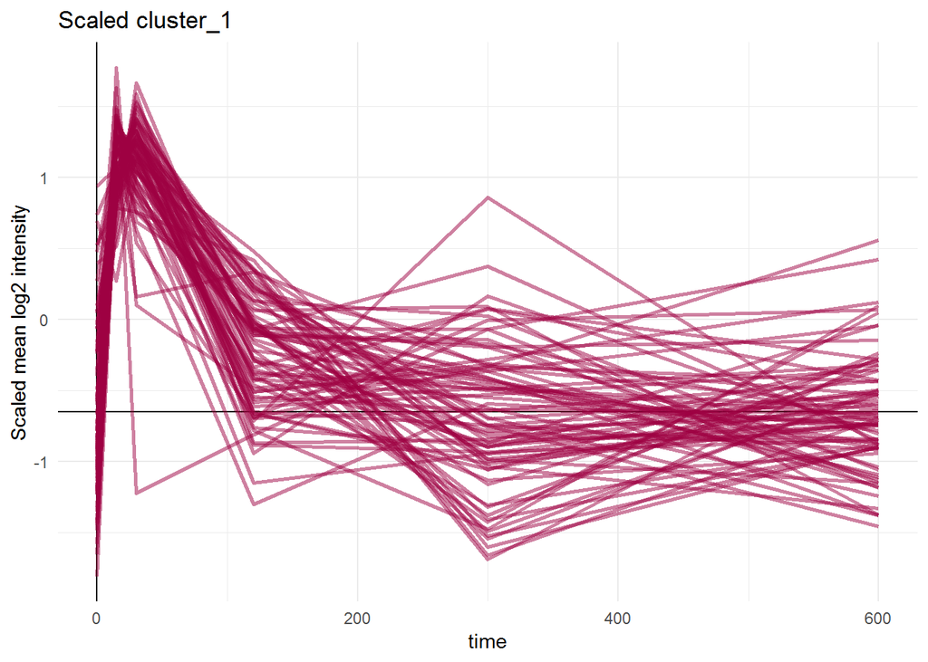

```
##  [1] "A2AF47_S12"                      "A2AF47_S1240"
##  [3] "B1AVY7_S838"                     "O09000_S847"
##  [5] "O35601_S318"                     "O35601_Y559"
##  [7] "O54824_S959"                     "O54824_S967"
##  [9] "O55131_T425"                     "O70400_S185"
## [11] "O89100_S163"                     "P13379_S438"
## [13] "P13379_T435"                     "P15864;P43277_S36;37"
## [15] "P20065_T27"                      "P20065_T29"
## [17] "P22682_Y672"                     "P29351_Y536"
## [19] "P29352_S452"                     "P30987_S328"
## [21] "P31938;Q63932_S222;226"          "P35821_S335"
## [23] "P48193_S703"                     "P54227_S16"
## [25] "P62482_S14"                      "P63085_Y185"
## [27] "P70218_S325"                     "P70429_S257"
## [29] "P70429_S258"                     "P70460_S318"
```

[output cut: 22 more lines]

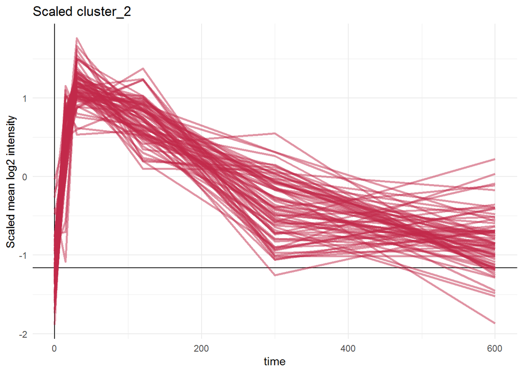

```
##  [1] "O35601_S203"            "O55098_S416"
##  [3] "P19973_S184"            "P22682_S617"
##  [5] "P22682_Y698"            "P33174_T800"
##  [7] "P35601_S363"            "P42209_Y5"
##  [9] "P42230_Y694"            "P43404_S490+Y492"
## [11] "P43404_T291"            "P43404_Y290"
## [13] "P43404_Y491"            "P47774_S365"
## [15] "P47941_Y251"            "P52633_Y641"
## [17] "P70429_S150"            "P70429_S329"
## [19] "P83741_S2367"           "P97465_S269"
## [21] "Q01965_Y625"            "Q04735;Q8K0D0_S119;146"
## [23] "Q3TTA7_Y708"            "Q3TTA7_Y889"
## [25] "Q3UZA1_S179"            "Q3V3E1_Y9"
## [27] "Q4QQM4_S14"             "Q62393_S175"
## [29] "Q6NZJ6_S1211"           "Q6P4S6_S1160"
## [31] "Q80TM6;Q9DCB4_S283;278" "Q80U16_S582"
## [33] "Q80U16_T581"            "Q811M1_S218"
## [35] "Q8BGD9_S497"            "Q8BZ03_S873"
## [37] "Q8CBW3_S231"            "Q8K212_S526"
## [39] "Q8R1G6_S209"            "Q8R5A3_S532+S537"
## [41] "Q9ERS5_S314"            "Q9ES28_S223"
## [43] "Q9ESJ0_S521"            "Q9QXL1_S1198"
```

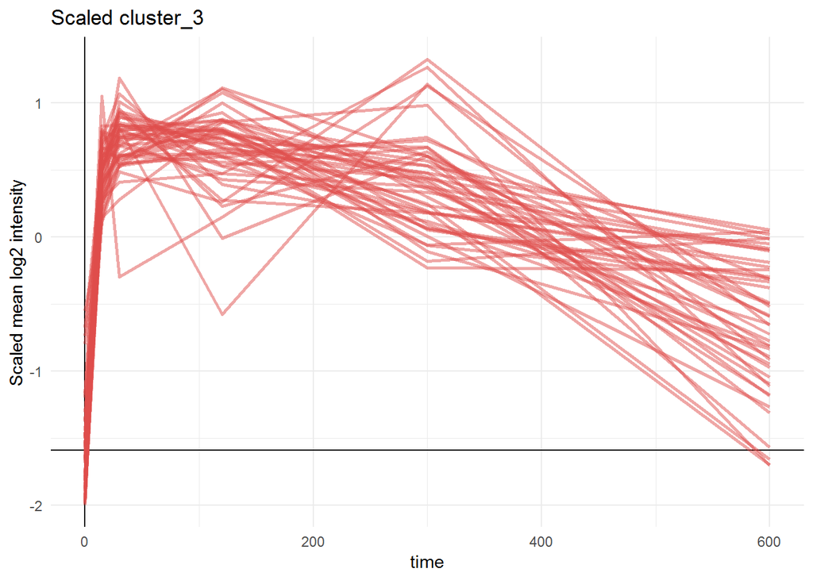

```
##  [1] "A6H8H2_S1274"
##  [2] "O35295_S6"
##  [3] "O35601_S207"
##  [4] "O89100_S186"
##  [5] "O89100_S230"
##  [6] "P05480;P06240;P39688;Q04736_Y424;394;420;424"
##  [7] "P11942_S148"
##  [8] "P19426_S115"
##  [9] "P25206_S668"
## [10] "P42228_Y694"
## [11] "P43404_Y492"
## [12] "P57016_S62"
## [13] "P57725_S90"
## [14] "P59729_S389"
## [15] "Q4VAA2_S51"
## [16] "Q60787_S376"
## [17] "Q68FF6_S601"
## [18] "Q6P9Q4_S514"
## [19] "Q7TPM1_S415"
## [20] "Q7TQ95_S411"
## [21] "Q8C147_S433"
## [22] "Q8C2K5_S74"
## [23] "Q8C3J5_S1704"
## [24] "Q8VDI1_S39"
## [25] "Q924A2_S2275+T2283"
```

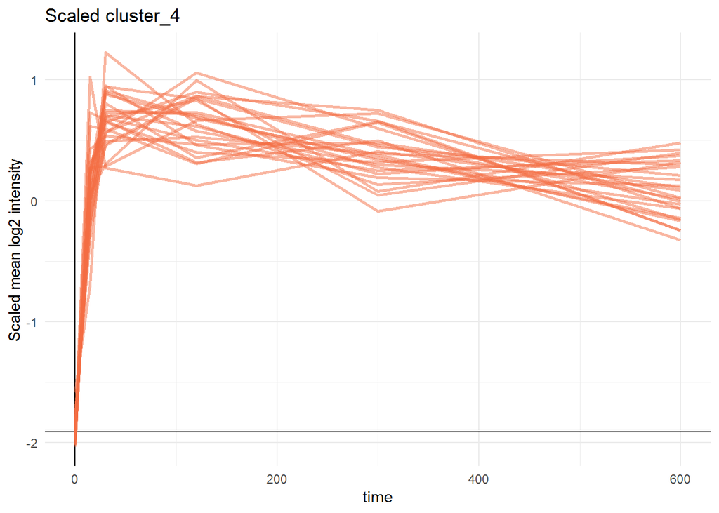

```
##  [1] "O35623_S50"         "O54824_S839"        "P18653_S369"
##  [4] "P18654_S386"        "P19426_S51"         "P33611_S126"
##  [7] "P47811_Y182"        "P49710_S62"         "P58854_S894"
## [10] "P97820_S629"        "Q3UZA1_S127"        "Q60591_S257"
## [13] "Q60787_T341"        "Q61026_S771"        "Q63844_Y205"
## [16] "Q6A068_S273"        "Q6NV83_S202"        "Q80WJ7_S303"
## [19] "Q8K2Z4_S1320"       "Q9CQT2_S136"        "Q9DBR7_S507"
## [22] "Q9JL26_T1018+S1021" "Q9WTX2_S18"         "Q9Z1W9_S383"
```

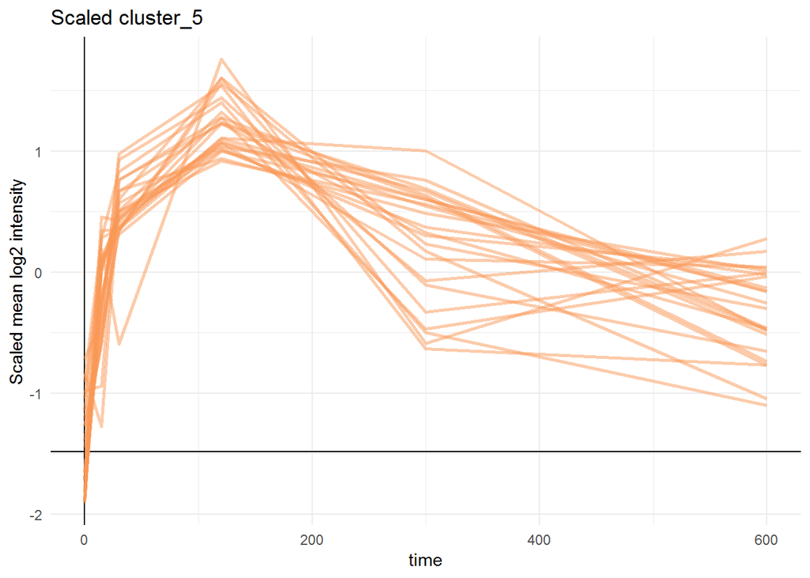

```
##   [1] "A2ALU4_T910+S917"       "A2AM29_S302"
##   [3] "A2APB8_S737"            "B2RWS6_S12"
##   [5] "E9Q1P8_S226"            "F6ZDS4_S2223"
##   [7] "G5E829_S1139"           "G5E829_S1140"
##   [9] "O35691_S66"             "O54916_S708"
##  [11] "O54967_Y842"            "O55098_T950"
##  [13] "O89053_T424"            "P04235_Y149+S161"
##  [15] "P09405_S403"            "P09405_S577"
##  [17] "P11031_S55"             "P12382_S775"
##  [19] "P22646_Y170"            "P29352_S537"
##  [21] "P33174_S802"            "P33609_S192"
##  [23] "P33609_T193"            "P37913_S65"
##  [25] "P42128_S406+S414"       "P43404_Y491+Y492"
##  [27] "P51125_T216"            "P51125_T309"
##  [29] "P53986_S477"            "P54227;P55821_S46;80"
```

[output cut: 40 more lines]

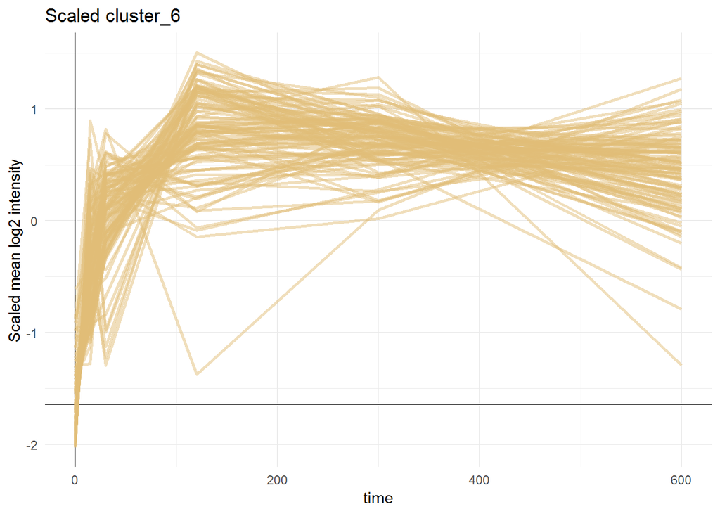

```
##  [1] "A2AJK6_S626"            "A2BH40_S1185"
##  [3] "D3YXK1_S150"            "D3YZP9_S237"
##  [5] "O88286_S1016"           "O88796_S251"
##  [7] "O88811_Y192"            "O88942_S235"
##  [9] "O89100_T254"            "P04370_S112"
## [11] "P08414_S337"            "P11942_Y160"
## [13] "P13864_S140"            "P14733_T21"
## [15] "P22646_Y181"            "P24161;P29020_Y111;111"
## [17] "P24161;P29020_Y123;123" "P24161;P29020_Y72;72"
## [19] "P24161;P29020_Y83;83"   "P24161_Y142"
## [21] "P24161_Y142+T152"       "P24161_Y153"
## [23] "P29020_Y142"            "P40201_S1619"
## [25] "P42227_S727"            "P46062_S72"
## [27] "P51125_S219"            "P54227_S25"
## [29] "P54227_S63"             "P54254_S62"
```

[output cut: 21 more lines]

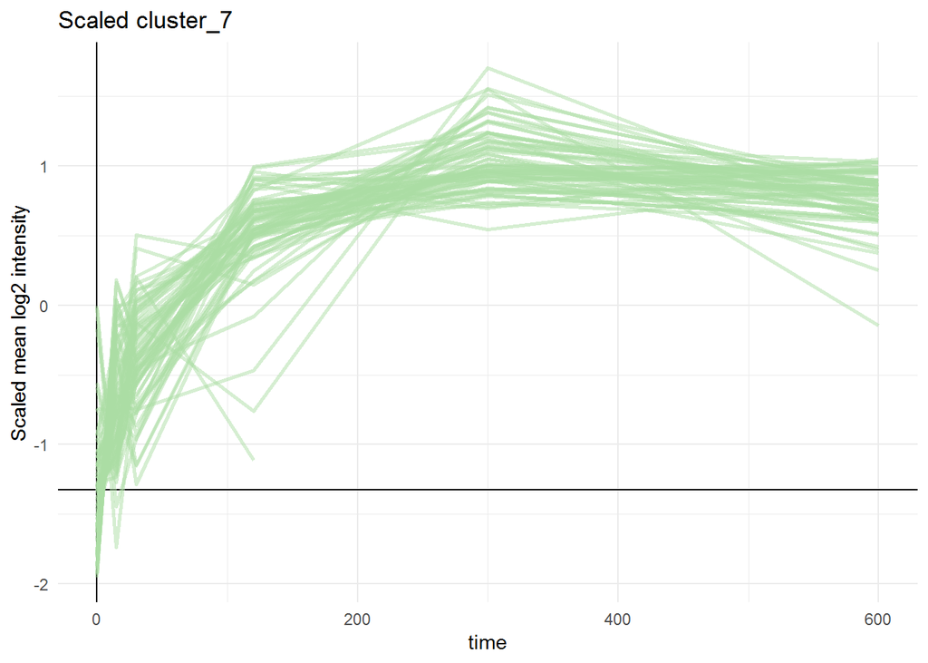

```
##   [1] "D3YXK2;Q80YR5_S366;387" "E9Q5G3_S160"
##   [3] "F6ZDS4_S720"            "O35381_S17"
##   [5] "O35892_S314"            "O70251_S106"
##   [7] "O70480_S17"             "O88532_S1054"
##   [9] "O88685_S12"             "O88746_S462"
##  [11] "O88811_Y371"            "P16951_T53"
##  [13] "P18608_S7"              "P28028_S135"
##  [15] "P35601_S244"            "P42128_S431"
##  [17] "P49312_S95"             "P50580_S2"
##  [19] "P53986_S210+S213"       "P58871_S1022"
##  [21] "P70460_S235"            "P97310_S108"
##  [23] "P97311_S13"             "P97360_T18+S22"
##  [25] "Q05D44_S108"            "Q14AX6_S382+S384"
##  [27] "Q3TBD2_S577+S591"       "Q3TBD2_S875"
##  [29] "Q3UMU9_S659"            "Q3UZ39_S302"
```

[output cut: 39 more lines]

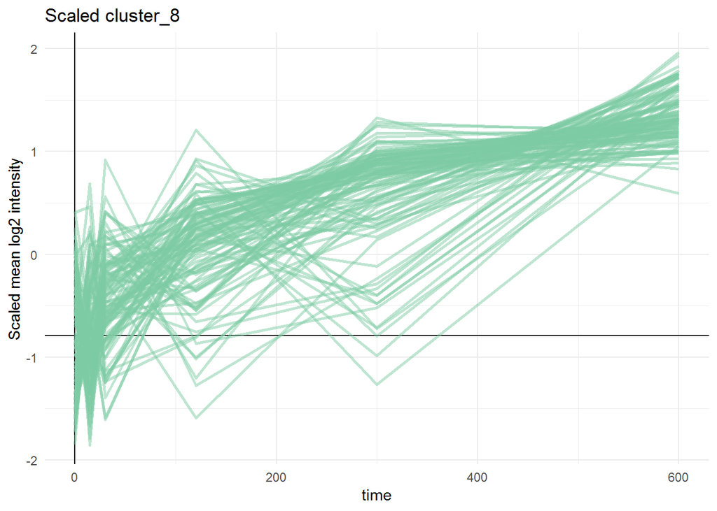

```
##  [1] "O35685_S136"            "O55187_S350"
##  [3] "P11031_S15"             "P43276_S18"
##  [5] "P49710_T330"            "Q61029;Q61033_T159;159"
##  [7] "Q63844_T203+Y205"       "Q8BTV2_S197"
##  [9] "Q8BYW1_S396"            "Q8C3J5_S1591"
## [11] "Q8K212_S527"            "Q8R1Q8_S510"
## [13] "Q8R3F9_S655"            "Q923A2_S552"
## [15] "Q99KG3_S723"            "Q99PV8_S381"
## [17] "Q9CYL5_S55"             "Q9D8T7_T104"
## [19] "Q9QZS3_S440"
```

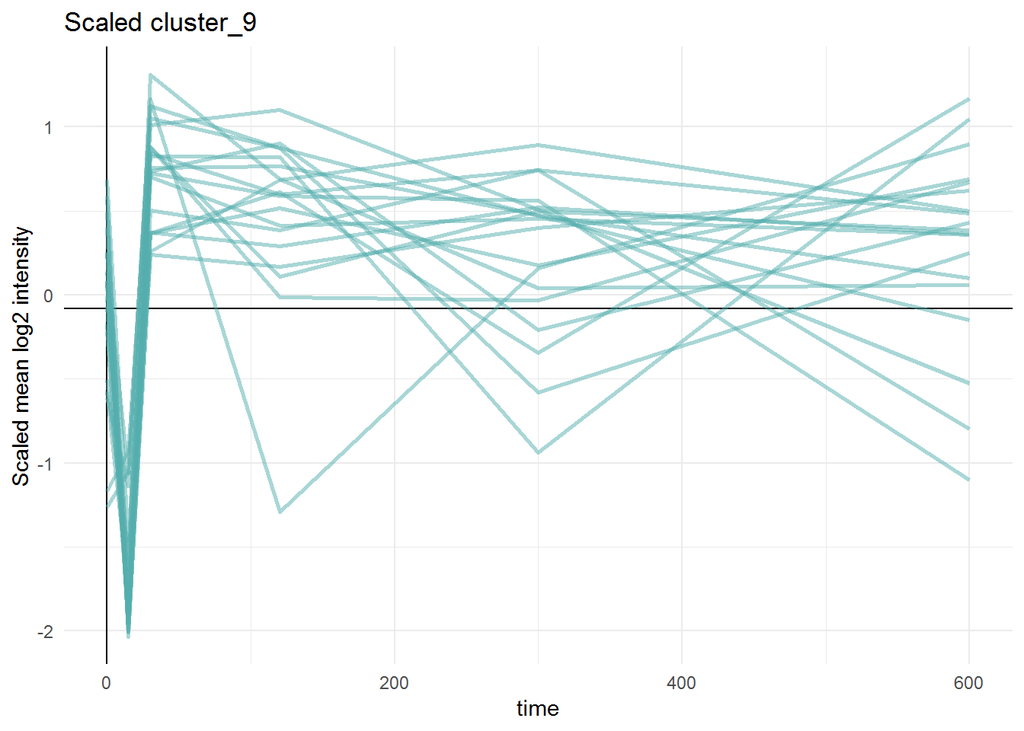

```
##  [1] "O35892_T182"            "O54774_S760"
##  [3] "O55029_S860"            "P13864_S138"
##  [5] "P16254_S45"             "P35550_S130"
##  [7] "P43346_S13"             "P46062_S65"
##  [9] "P57776_S162"            "Q3TLH4_S899"
## [11] "Q3UI43_T10"             "Q60823_T451"
## [13] "Q60875_T152"            "Q61103_S244"
## [15] "Q6NVE8_S346"            "Q6PDK2_S2318"
## [17] "Q6ZQ03_S440"            "Q8BTI8_S1577"
## [19] "Q8BTI8_S2347"           "Q8BWJ3_S729"
## [21] "Q8CHY6_S543"            "Q8R5A3_S532"
## [23] "Q922J3;Q9Z0H8_S347;353" "Q924Z5_S332"
## [25] "Q9CQY2_S36"             "Q9CWE0_S235"
## [27] "Q9JKB3_S328"            "Q9QUG9_S554"
## [29] "Q9R233_S461"            "Q9Z2U4_S187"
```

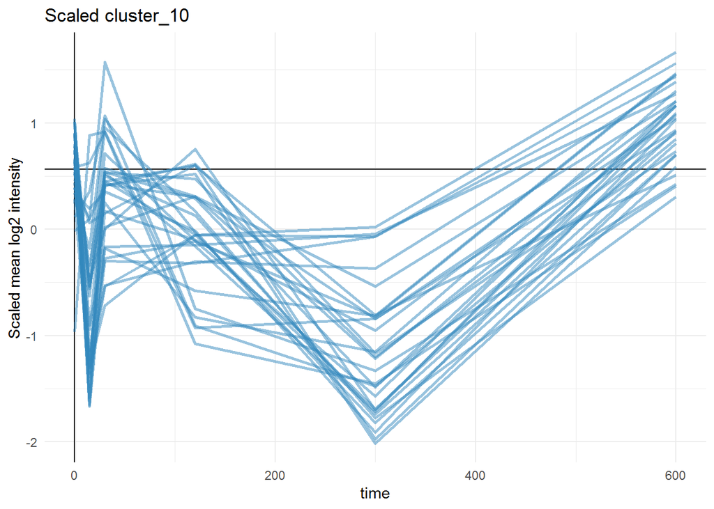

```
##  [1] "A6H619_S1045"         "O08539_S332"          "O08547_S137"
##  [4] "O35892_S168"          "O54962_S4"            "P11157_S20"
##  [7] "P27546_S1046"         "P29352_S512"          "P42128_S406"
## [10] "P51125_S11"           "P60335_S189"          "P70227_S1832"
## [13] "P70227_S934"          "P70288_S422"          "P83093_S28"
## [16] "P83510_S651"          "Q3THE2;Q9CQ19_T19;19" "Q3U214_S769"
## [19] "Q3U9G9_S177"          "Q3V3V9_S1242"         "Q60591_S136+S150"
## [22] "Q60591_S238+S245"     "Q61029_S305"          "Q61136_S88+S94"
## [25] "Q640Q5_S300"          "Q6A0D4_S536"          "Q6P4S6_S616"
## [28] "Q6P4S6_S964"          "Q6PDQ2_S296"          "Q6PHZ5_S263"
## [31] "Q6ZPZ3_S1111"         "Q6ZQ58_S743"          "Q80UG5_S82"
## [34] "Q8BJS4_S281"          "Q8BLH7_T167"          "Q8BTI8_S2075"
## [37] "Q8BTI8_S300"          "Q8C0V0_S22"           "Q8K124_S395"
## [40] "Q8K212_T502"          "Q8K352_S27"           "Q8K394_S18"
## [43] "Q8K3H0_S401"          "Q99NH0_S2401"         "Q9D4F2_S67"
## [46] "Q9DBG5_S245"          "Q9DC04_S686"          "Q9DC04_S776"
## [49] "Q9DC04_T710"          "Q9JL26_S184"          "Q9QYG0_S332"
```

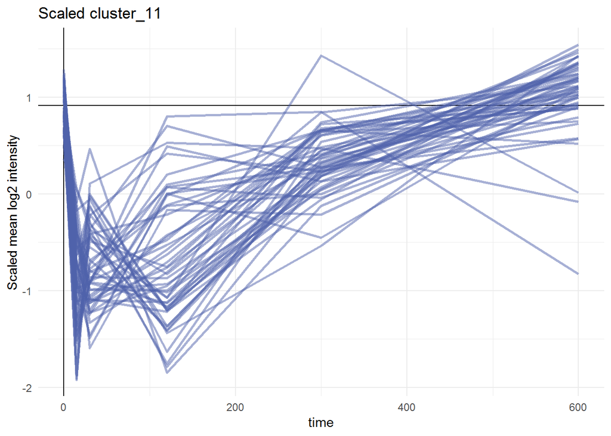

```
##  [1] "A2A6A1_S735"           "A2AJT4_S211"
##  [3] "A2CG63_S839"           "B2RX14_S131"
##  [5] "O08582_S8"             "P11440_Y15"
##  [7] "P14733_S14"            "P16546_S1029"
##  [9] "P16546_S1031"          "P19973_T166+S168+S180"
## [11] "P38532_S303"           "P43274_T18+S2"
## [13] "P53986_S210"           "P58252_T57"
## [15] "P58252_T57+T59"        "P70302_S521"
## [17] "P70441_S297"           "P70658_S332"
## [19] "P70671_S135"           "P83093_S626"
## [21] "P83093_S678"           "P97303_S314"
## [23] "P97814_S318"           "Q3TBD2_S23"
## [25] "Q3TBD2_S591"           "Q3UHJ0_S635"
## [27] "Q3UMU9_S367"           "Q3V3V9_S1214"
## [29] "Q5SWU9_S79"            "Q60591_S136"
## [31] "Q60591_S365"           "Q61029_S314"
## [33] "Q63943_S180"           "Q63943_S251"
## [35] "Q6RT24_S2383"          "Q7TPV4_S1325"
## [37] "Q80UG5_S85"            "Q8BTI8_S990"
## [39] "Q8BUM3_S44"            "Q8BZ03_S197"
## [41] "Q8C2B3_T342"           "Q8CBW3_S225"
## [43] "Q8K394_S87"            "Q91YD3_T420"
## [45] "Q99K74_S871"           "Q99LI2_S429"
## [47] "Q9CWE0_S100"           "Q9D4J7_S199"
## [49] "Q9D8C4_T34"            "Q9QZQ1_S1275"
## [51] "Q9R078_S108"           "Q9WUU8_S416"
```

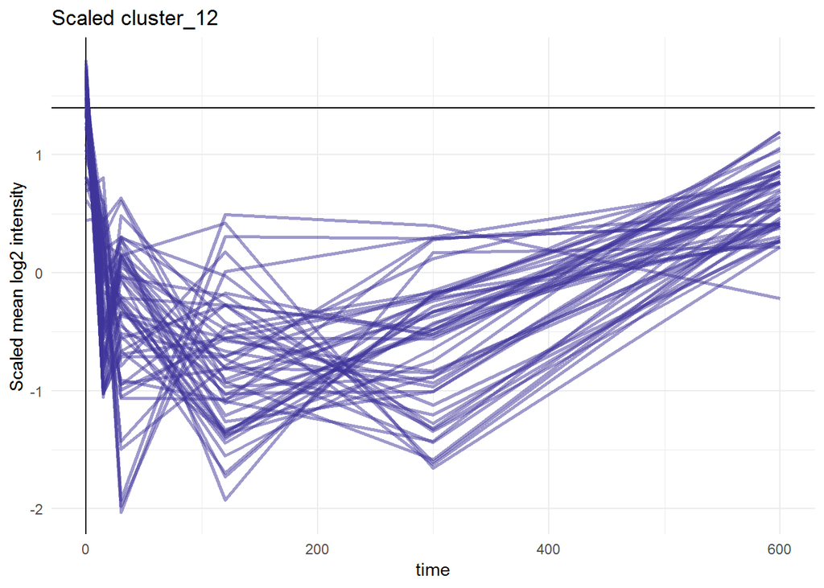

```
##  [1] "A2AJI0_S401"          "O35601_S114"          "P10126;P62631_Y29;29"
##  [4] "P18760_S3"            "P19973_S168"          "P19973_T166+S168"
##  [7] "P57725_S23"           "P57776_S118"          "P83093_S680"
## [10] "P83093_S719"          "Q00196_S55"           "Q4QRL3_S1413"
## [13] "Q60591_S328"          "Q60664_S362"          "Q61127_S159"
## [16] "Q61210_S775"          "Q61656_S24"           "Q61656_T26"
## [19] "Q69ZX6_S741"          "Q6A0A2_T735"          "Q6PCP5_S129"
## [22] "Q6ZQ58_T503"          "Q7TN58_S666"          "Q80TV8_S794"
## [25] "Q8BHK9_S852"          "Q8BTI8_S984"          "Q8CHP6_T607"
## [28] "Q8CI11_T501"          "Q8K136_S178"          "Q8K4G5_S789"
## [31] "Q8R1G6_S199"          "Q8R502_T198"          "Q8R550_S630"
## [34] "Q8R550_S631"          "Q922Y1_S188"          "Q9D5V6_T262"
## [37] "Q9DBR7_S445"          "Q9EQN3_T167"          "Q9ERH7_Y359"
## [40] "Q9JM52_S729"          "Q9QWY8_S854"          "Q9R0P5_S3"
## [43] "Q9R1K9_S20"           "Q9Z0R6_S838+S843"
```

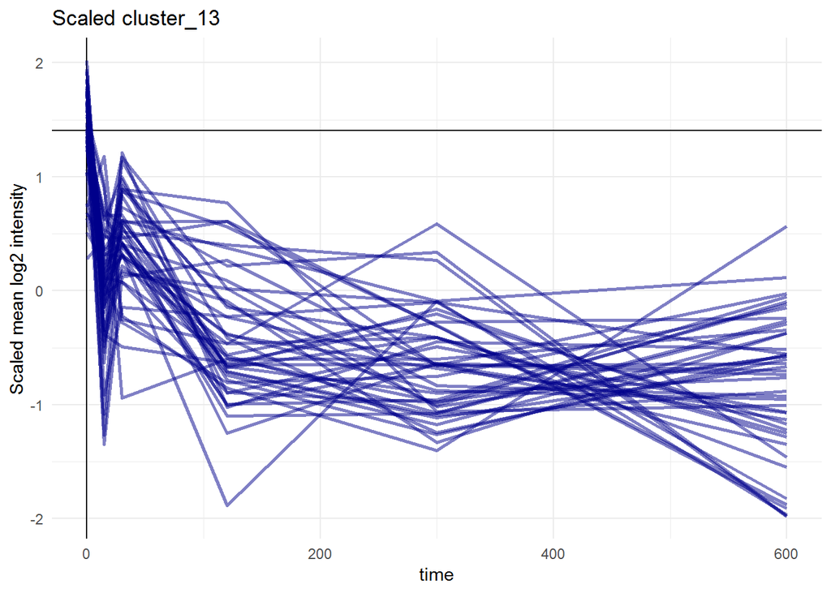

Repartition of the regulated pS, pT and pY per cluster:

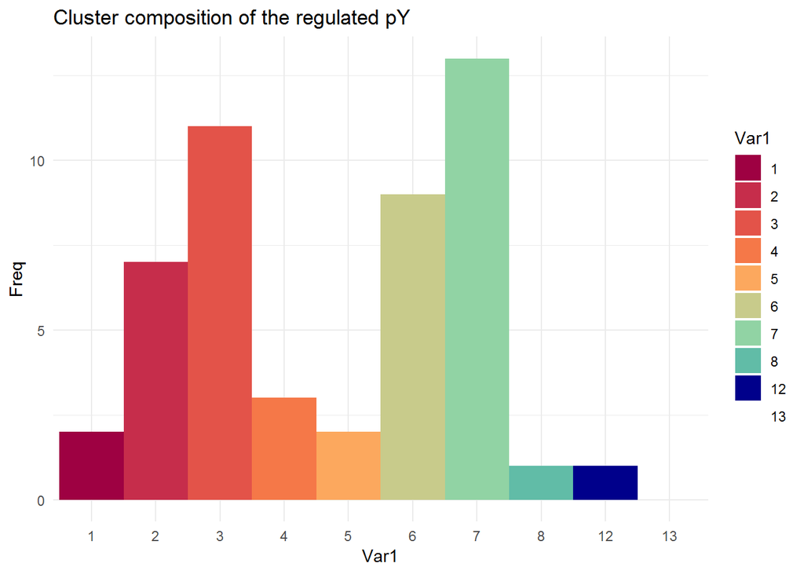

|  | Var1 | Freq | pos | facet |
| --- | --- | --- | --- | --- |
| 1 | 1 | 2 | 0.9803922 | up |
| 4 | 2 | 7 | 0.8921569 | up |
| 5 | 3 | 11 | 0.7156863 | up |
| 6 | 4 | 3 | 0.5784314 | up |
| 7 | 5 | 2 | 0.5294118 | down |
| 8 | 6 | 9 | 0.4215686 | down |
| 9 | 7 | 13 | 0.2058824 | down |
| 10 | 8 | 1 | 0.0686275 | down |
| 2 | 12 | 1 | 0.0490196 | Mixed |
| 3 | 13 | 2 | 0.0196078 | down |

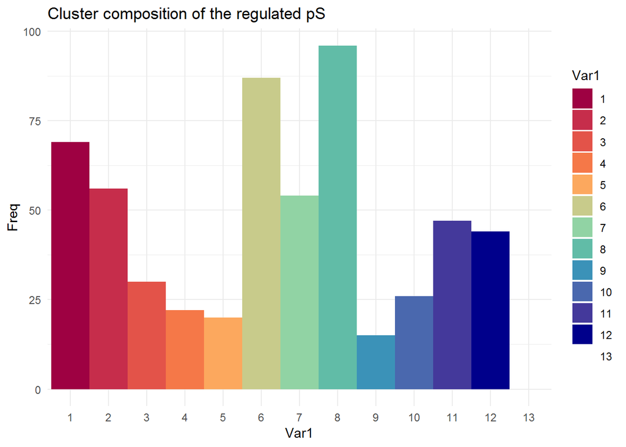

|  | Var1 | Freq | pos | facet |
| --- | --- | --- | --- | --- |
| 1 | 1 | 69 | 0.9424040 | up |
| 6 | 2 | 56 | 0.8380634 | up |
| 7 | 3 | 30 | 0.7662771 | up |
| 8 | 4 | 22 | 0.7228715 | up |
| 9 | 5 | 20 | 0.6878130 | down |
| 10 | 6 | 87 | 0.5984975 | down |
| 11 | 7 | 54 | 0.4808013 | down |
| 12 | 8 | 96 | 0.3555927 | down |
| 13 | 9 | 15 | 0.2629382 | down |
| 2 | 10 | 26 | 0.2287145 | down |
| 3 | 11 | 47 | 0.1677796 | down |
| 4 | 12 | 44 | 0.0918197 | Mixed |
| 5 | 13 | 33 | 0.0275459 | down |

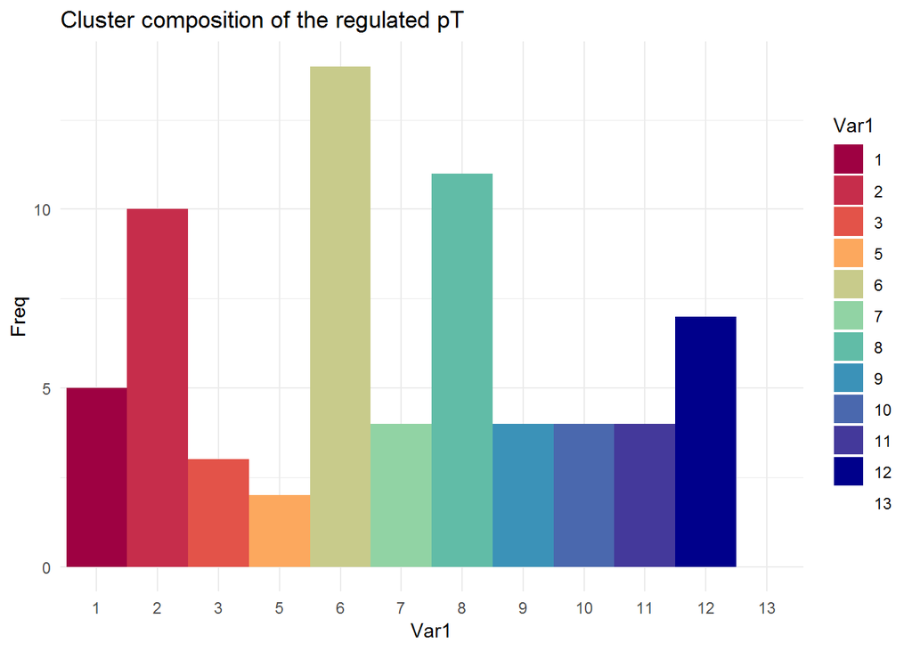

|  | Var1 | Freq | pos | facet |
| --- | --- | --- | --- | --- |
| 1 | 1 | 5 | 0.9675325 | up |
| 6 | 2 | 10 | 0.8701299 | up |
| 7 | 3 | 3 | 0.7857143 | up |
| 8 | 5 | 2 | 0.7532468 | down |
| 9 | 6 | 14 | 0.6493506 | down |
| 10 | 7 | 4 | 0.5324675 | down |
| 11 | 8 | 11 | 0.4350649 | down |
| 12 | 9 | 4 | 0.3376623 | down |
| 2 | 10 | 4 | 0.2857143 | down |
| 3 | 11 | 4 | 0.2337662 | down |
| 4 | 12 | 7 | 0.1623377 | Mixed |
| 5 | 13 | 9 | 0.0584416 | down |

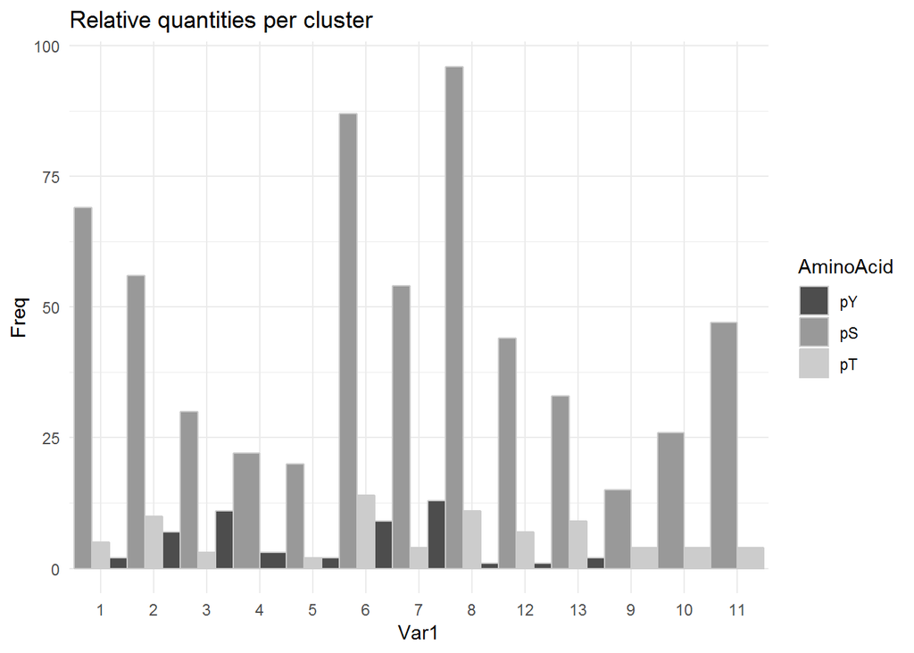

**Phospho-tyrosines are over-represented in the up-regulated clusters.**

## Graphical representation

I create a tile map with the replicate values per cluster.

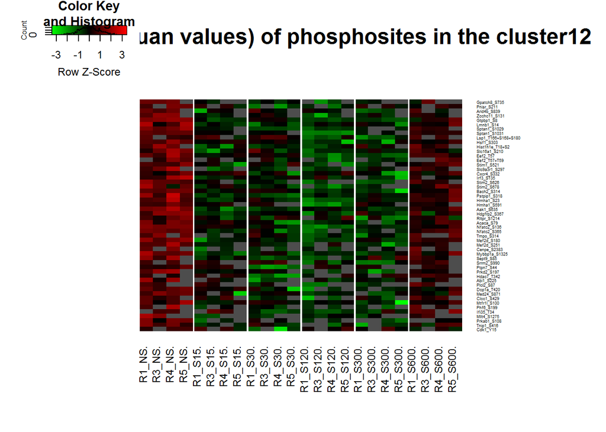

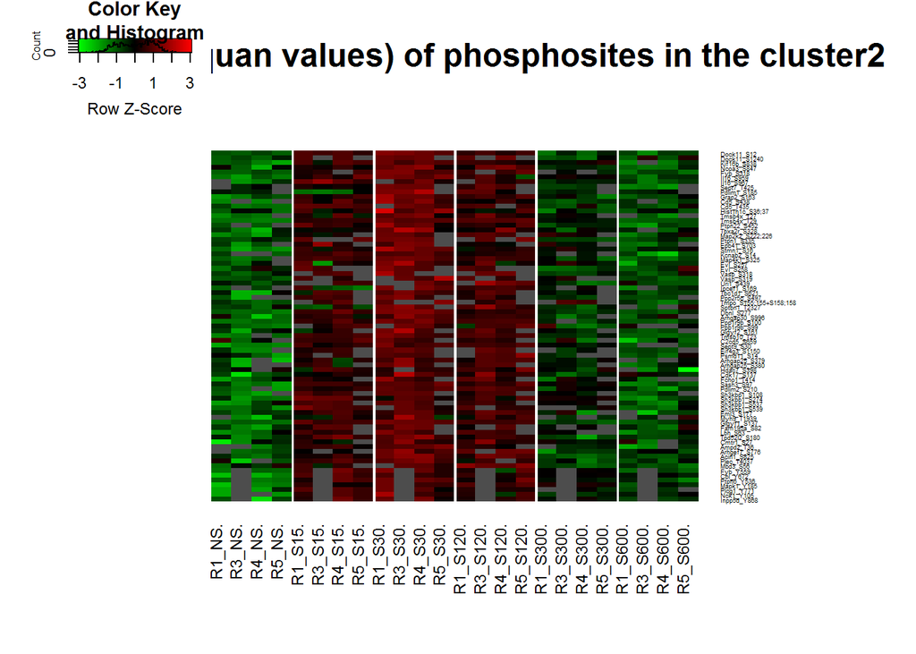

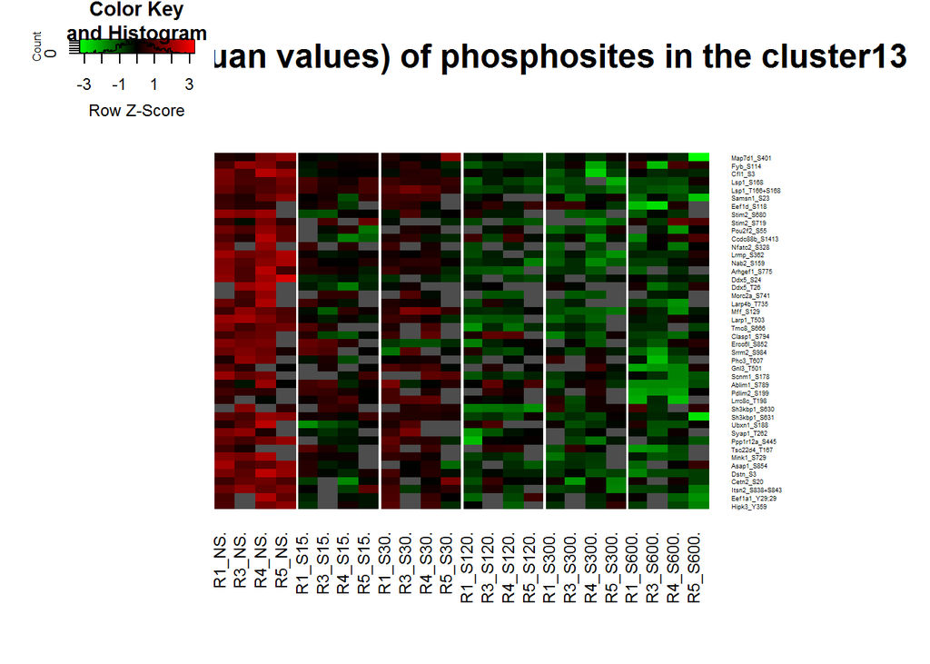

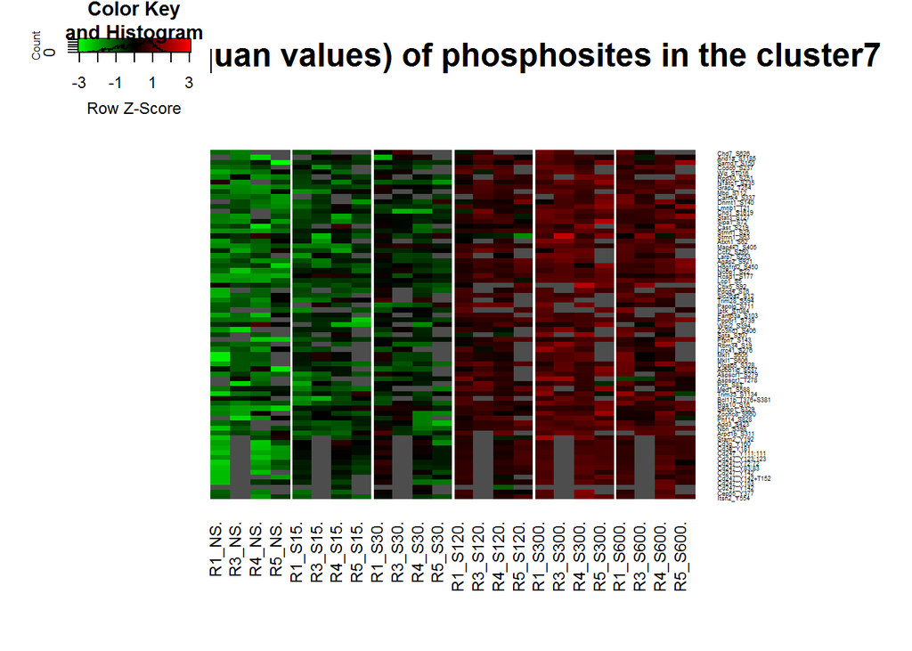

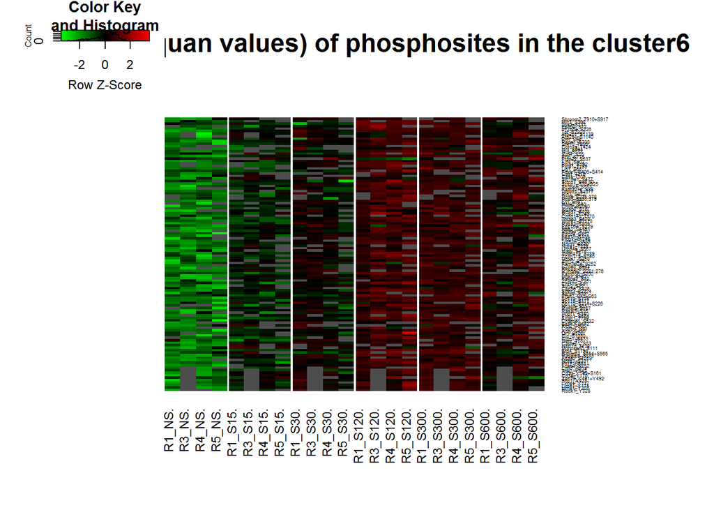

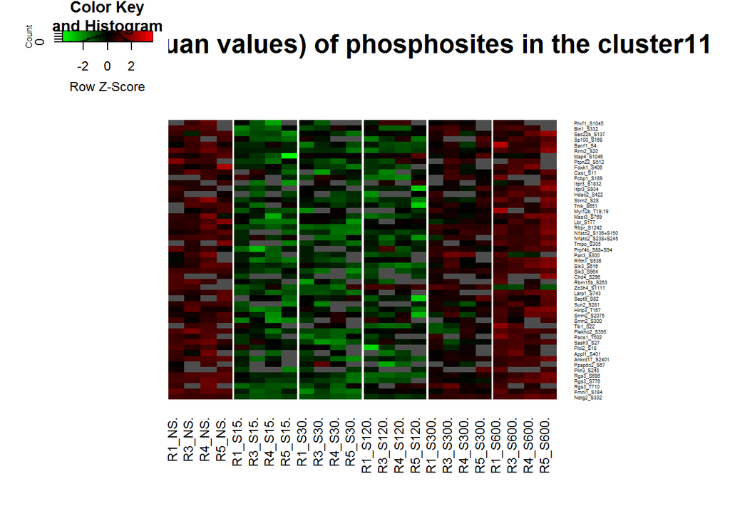

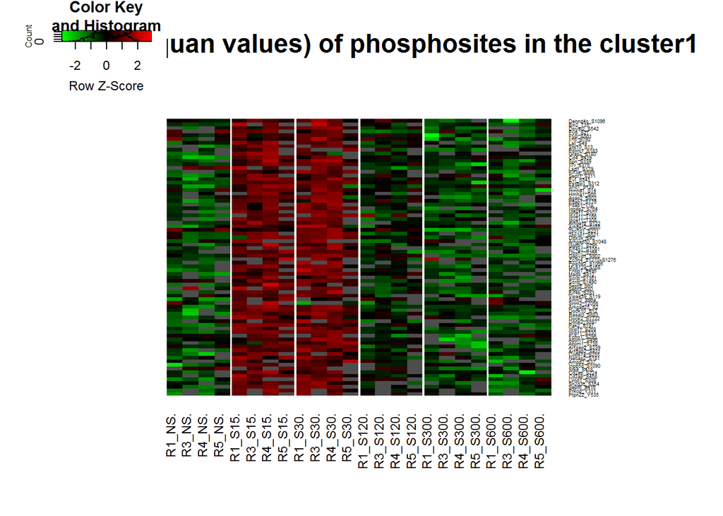

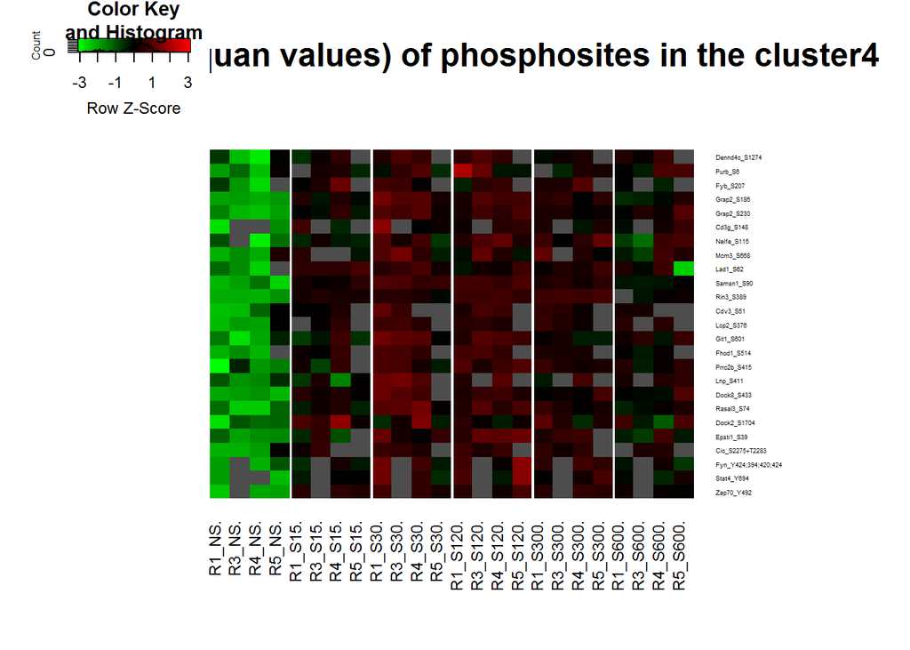